# Project Python Foundations: FoodHub Data Analysis

### Context

The number of restaurants in New York is increasing day by day. Lots of students and busy professionals rely on those restaurants due to their hectic lifestyles. Online food delivery service is a great option for them. It provides them with good food from their favorite restaurants. A food aggregator company FoodHub offers access to multiple restaurants through a single smartphone app.

The app allows the restaurants to receive a direct online order from a customer. The app assigns a delivery person from the company to pick up the order after it is confirmed by the restaurant. The delivery person then uses the map to reach the restaurant and waits for the food package. Once the food package is handed over to the delivery person, he/she confirms the pick-up in the app and travels to the customer's location to deliver the food. The delivery person confirms the drop-off in the app after delivering the food package to the customer. The customer can rate the order in the app. The food aggregator earns money by collecting a fixed margin of the delivery order from the restaurants.

### Objective

The food aggregator company has stored the data of the different orders made by the registered customers in their online portal. They want to analyze the data to get a fair idea about the demand of different restaurants which will help them in enhancing their customer experience. Suppose you are hired as a Data Scientist in this company and the Data Science team has shared some of the key questions that need to be answered. Perform the data analysis to find answers to these questions that will help the company to improve the business.

### Data Description

The data contains the different data related to a food order. The detailed data dictionary is given below.

### Data Dictionary

- order_id: Unique ID of the order
- customer_id: ID of the customer who ordered the food
- restaurant_name: Name of the restaurant
- cuisine_type: Cuisine ordered by the customer
- cost_of_the_order: Cost of the order
- day_of_the_week: Indicates whether the order is placed on a weekday or weekend (The weekday is from Monday to Friday and the weekend is Saturday and Sunday)
- rating: Rating given by the customer out of 5
- food_preparation_time: Time (in minutes) taken by the restaurant to prepare the food. This is calculated by taking the difference between the timestamps of the restaurant's order confirmation and the delivery person's pick-up confirmation.
- delivery_time: Time (in minutes) taken by the delivery person to deliver the food package. This is calculated by taking the difference between the timestamps of the delivery person's pick-up confirmation and drop-off information

### Let us start by importing the required libraries

```python
# Installing the libraries with the specified version.
!pip install numpy==1.25.2 pandas==1.5.3 matplotlib==3.7.1 seaborn==0.13.1 -q --user
```

[output not shown]

**Note**: *After running the above cell, kindly restart the notebook kernel and run all cells sequentially from the start again.*

```python
# import libraries for data manipulation
import numpy as np
import pandas as pd

# import libraries for data visualization
import matplotlib.pyplot as plt
import seaborn as sns
```

### Understanding the structure of the data

```python
# uncomment and run the following lines for Google Colab
from google.colab import drive
drive.mount('/content/drive')
```

```python
# Write your code here to read the data
# read file from google drive /Colab/proj1/foodhub_order.csv

import pandas as pd
df = pd.read_csv('/content/drive/My Drive/Colab/proj1/foodhub_order.csv')
```

```python
# Write your code here to view the first 5 rows

df.head()
```

|  | order_id | customer_id | restaurant_name | cuisine_type | cost_of_the_order | day_of_the_week | rating | food_preparation_time | delivery_time |
| --- | --- | --- | --- | --- | --- | --- | --- | --- | --- |
| 0 | 1477147 | 337525 | Hangawi | Korean | 30.75 | Weekend | Not given | 25 | 20 |
| 1 | 1477685 | 358141 | Blue Ribbon Sushi Izakaya | Japanese | 12.08 | Weekend | Not given | 25 | 23 |
| 2 | 1477070 | 66393 | Cafe Habana | Mexican | 12.23 | Weekday | 5 | 23 | 28 |
| 3 | 1477334 | 106968 | Blue Ribbon Fried Chicken | American | 29.20 | Weekend | 3 | 25 | 15 |
| 4 | 1478249 | 76942 | Dirty Bird to Go | American | 11.59 | Weekday | 4 | 25 | 24 |

### **Question 1:** How many rows and columns are present in the data? [0.5 mark]

```python
# Check the number of rows and columns in the data
print(f"Number of rows: {df.shape[0]}")
print(f"Number of columns: {df.shape[1]}")
```

```
Number of rows: 1898
Number of columns: 9
```

#### Observations:

Number of rows: 1898  
Number of columns: 9

**Dataset Shape:** `df.shape` → (1,898, 9)

### **Question 2:** What are the datatypes of the different columns in the dataset? (The info() function can be used) [0.5 mark]

```python
# Use info() to find the datatypes of the columns
df.info()
```

```
<class 'pandas.core.frame.DataFrame'>
RangeIndex: 1898 entries, 0 to 1897
Data columns (total 9 columns):
 #   Column                 Non-Null Count  Dtype
---  ------                 --------------  -----
 0   order_id               1898 non-null   int64
 1   customer_id            1898 non-null   int64
 2   restaurant_name        1898 non-null   object
 3   cuisine_type           1898 non-null   object
 4   cost_of_the_order      1898 non-null   float64
 5   day_of_the_week        1898 non-null   object
 6   rating                 1898 non-null   object
 7   food_preparation_time  1898 non-null   int64
 8   delivery_time          1898 non-null   int64
dtypes: float64(1), int64(4), object(4)
memory usage: 133.6+ KB
```

#### Observations:

```
 #   Column                 Non-Null Count  Dtype
---  ------                 --------------  -----
 0   order_id               1898 non-null   int64
 1   customer_id            1898 non-null   int64
 2   restaurant_name        1898 non-null   object
 3   cuisine_type           1898 non-null   object
 4   cost_of_the_order      1898 non-null   float64
 5   day_of_the_week        1898 non-null   object
 6   rating                 1898 non-null   object
 7   food_preparation_time  1898 non-null   int64
 8   delivery_time          1898 non-null   int64
```

### **Question 3:** Are there any missing values in the data? If yes, treat them using an appropriate method. [1 mark]

```python
print(df.isnull().sum())
```

```
order_id                 0
customer_id              0
restaurant_name          0
cuisine_type             0
cost_of_the_order        0
day_of_the_week          0
rating                   0
food_preparation_time    0
delivery_time            0
dtype: int64
```

#### Observations:

There are no missing values within this CSV.

After full analysis: no other missing values exist besides the 736 ‘Not given’ ratings (38.8% of orders).

**Missing Values:**

- `rating`: 736 missing (“Not given”)
- All other columns: 0 missing

### **Question 4:** Check the statistical summary of the data. What is the minimum, average, and maximum time it takes for food to be prepared once an order is placed? [2 marks]

```python
# Get the summary statistics of the numerical columns
print(df.describe().T)
```

```
                        count          mean            std         min  \
order_id               1898.0  1.477496e+06     548.049724  1476547.00
customer_id            1898.0  1.711685e+05  113698.139743     1311.00
cost_of_the_order      1898.0  1.649885e+01       7.483812        4.47
food_preparation_time  1898.0  2.737197e+01       4.632481       20.00
delivery_time          1898.0  2.416175e+01       4.972637       15.00

                              25%         50%           75%         max
order_id               1477021.25  1477495.50  1.477970e+06  1478444.00
customer_id              77787.75   128600.00  2.705250e+05   405334.00
cost_of_the_order           12.08       14.14  2.229750e+01       35.41
food_preparation_time       23.00       27.00  3.100000e+01       35.00
delivery_time               20.00       25.00  2.800000e+01       33.00
```

#### Observations:

Minimum food preparation time: 20 minutes  
Average food preparation time: 27.37 minutes  
Maximum food preparation time: 35 minutes

### **Question 5:** How many orders are not rated? [1 mark]

```python
non_rated_orders = df['rating'].value_counts()['Not given']
print(f"Number of orders not rated: {non_rated_orders}")
```

```
Number of orders not rated: 736
```

#### Observations:

736 orders have not been rated.

### Exploratory Data Analysis (EDA)

### **Question 6:** Explore all the variables and provide observations on their distributions. (Generally, histograms, boxplots, countplots, etc. are used for univariate exploration.) [9 marks]

```python
import matplotlib.pyplot as plt
# Set a clean, readable theme
sns.set(style="whitegrid", palette="deep")
```

```python
# Add the table for the top 5 restaurants
print("Top 5 Restaurants by Number of Orders:")
print(df['restaurant_name'].value_counts().head(5).to_markdown(numalign="left", stralign="left"))

# Calculate the percentage of orders for the top 5 restaurants
top_5_restaurants = df['restaurant_name'].value_counts().head(5)
total_orders = df.shape[0]
percentage_top_5 = (top_5_restaurants.sum() / total_orders) * 100

# Generate the bullet point commentary
top_5_commentary = "The top five restaurants by total orders are "
for i, (restaurant, count) in enumerate(top_5_restaurants.items()):
    top_5_commentary += f"{restaurant} ({count} orders)"
    if i < len(top_5_restaurants) - 2:
        top_5_commentary += ", "
    elif i == len(top_5_restaurants) - 2:
        top_5_commentary += ", and "
top_5_commentary += f" which collectively make up ~{percentage_top_5:.1f}% of all orders."
print(f"\n- {top_5_commentary}")
```

```
Top 5 Restaurants by Number of Orders:
| restaurant_name           | count   |
|:--------------------------|:--------|
| Shake Shack               | 219     |
| The Meatball Shop         | 132     |
| Blue Ribbon Sushi         | 119     |
| Blue Ribbon Fried Chicken | 96      |
| Parm                      | 68      |

- The top five restaurants by total orders are Shake Shack (219 orders), The Meatball Shop (132 orders), Blue Ribbon Sushi (119 orders), Blue Ribbon Fried Chicken (96 orders), and Parm (68 orders) which collectively make up ~33.4% of all orders.
```

```python
unique_counts_df = pd.DataFrame(df.nunique()).reset_index()
unique_counts_df.columns = ['Column Name', 'Unique Count']
print("Unique Value Counts as a Table:")
print(unique_counts_df.to_markdown(numalign="left", stralign="left"))
```

[output not shown]

#### Using Histograms(with KDE) and Boxplots for numeric columns

```python
# numeric_cols = ['cost_of_the_order', 'food_preparation_time', 'delivery_time']
def drawHistogramAndBoxplot(col):
    plt.figure(figsize=(8, 4))
    # Histogram with KDE
    sns.histplot(df[col], kde=True)
    plt.axvline(df[col].mean(), linestyle='--', label='mean')
    plt.axvline(df[col].median(), linestyle='-', label='median')
    plt.legend()
    plt.title(f"{col.replace('_',' ').title()} Distribution")
    plt.xlabel(col)
    plt.ylabel("Count")
    plt.show()

    plt.figure(figsize=(8, 2))
    # Boxplot
    sns.boxplot(x=df[col])
    plt.title(f"{col.replace('_',' ').title()} Boxplot")
    plt.xlabel(col)
    plt.show()
```

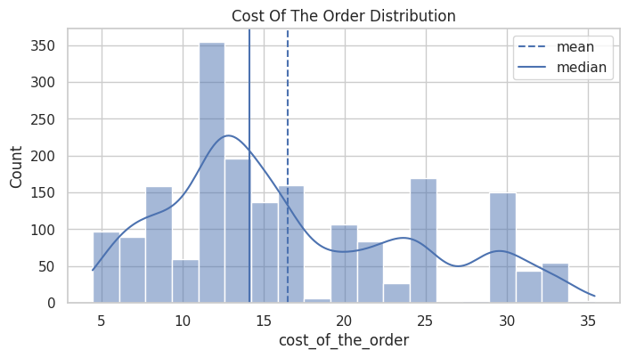

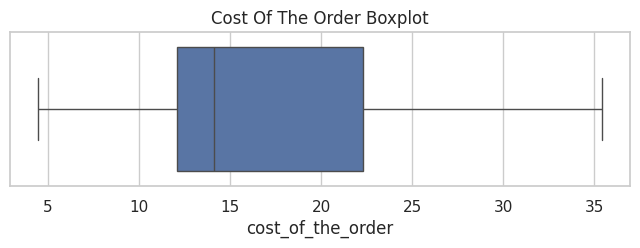

```python
drawHistogramAndBoxplot('cost_of_the_order')
```

orders cost between ~5 dollars to ~35 dollars

median cost is about 14 dollars

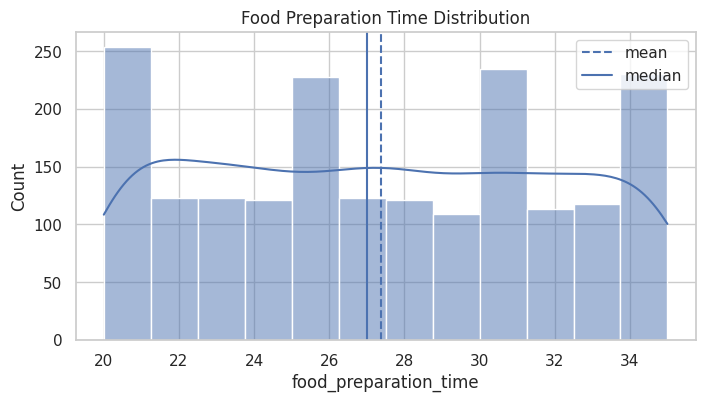

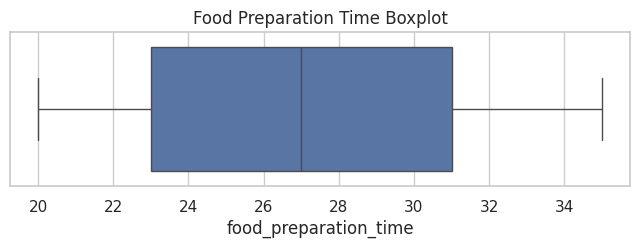

```python
drawHistogramAndBoxplot('food_preparation_time')
```

orders take between 20 to ~35 minutes

median food prep time is 27 minutes

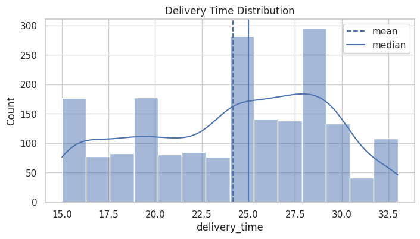

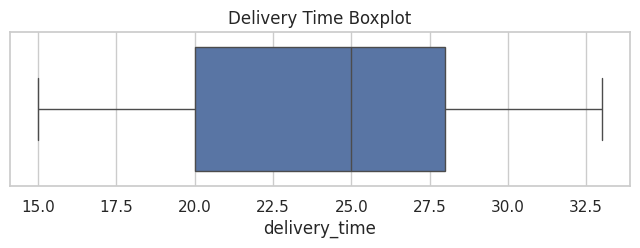

```python
drawHistogramAndBoxplot('delivery_time')
```

Delivery time takes 15 to ~33 minutes

median delivery time is 25 minutues.

#### Countplots for categorical columns

```python
# cat_cols = ['cuisine_type', 'day_of_the_week', 'rating']
def drawCountPlot(col):
    plt.figure(figsize=(8, 4))
    ax = sns.countplot(data=df, x=col, hue=col, palette='deep', order=df[col].value_counts().index, legend=False)
    for p in ax.patches:
        ax.annotate(int(p.get_height()), (p.get_x()+p.get_width()/2, p.get_height()), ha='center', va='bottom')
    plt.title(f"Order Counts by {col.replace('_',' ').title()}")
    plt.xticks(rotation=90)
    plt.xlabel(col)
    plt.ylabel("Number of Orders")
    plt.show()
```

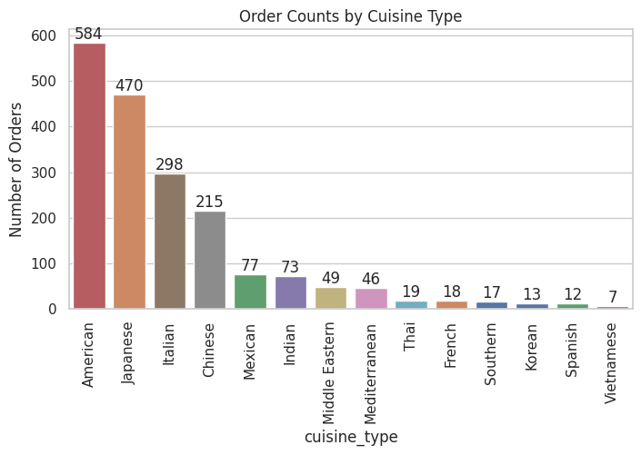

```python
drawCountPlot('cuisine_type')
```

**American and Japanese** food seems to be top ordered cuisines.

Can look at it in two ways.

1. The top cuisines are higher in demand for existing users. An information that can be used to **increase and maintain engagement through partnerships with popular restaurants and marketing the service showcasing top cuisines**.
2. The cuisines with much less order can be seen as a gap or opportunity. **There can be additional traffic if the service catered to users with preference to other cuisines**

Both information in this case seems very relevant. Depending on the Business goals we can choose either path.

- **Marketing while leveraging currently popular cuisine** will be the more common path for accelerating growth. The path is already proven to be effective by current data and exposure to existing customers. This growth path also has some level of assurance for immediate returns.
- **Taking the lack of orders from other less popular cuisines and trying to break into other demographic** could be another method for growth but usually this path is taken by services that has reached growth limits with their initial plans since it is associated with higher risk/cost and less immediate return.

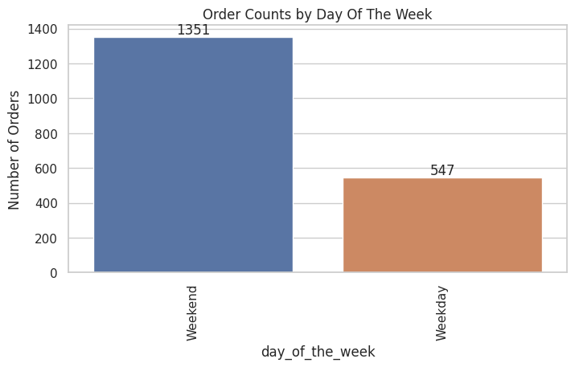

```python
drawCountPlot('day_of_the_week')
```

There are more orders on the weekends then on weekdays. Higher foot traffic from Monday through Friday work schedules naturually generate local spending habits. The weekends must be when most people are ordering digitally.

Might be an opportunity to try to advertise for new engagements as well as repeat customers. A good information for marketing.

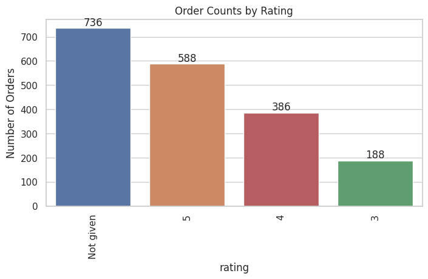

```python
drawCountPlot('rating')
```

There's quite a lot of "Not given" ratings on the orders. It might be a blindspot if there's too many orders without ratings.

And there's only 5, 4, 3 as ratings. is this due to the limitation in the options? Seems like most people are pretty satisfied when they give ratings.

Increasing engagement with ratings might help us gain more insight.

### **Question 7**: Which are the top 5 restaurants in terms of the number of orders received? [1 mark]

#### Top restaurants barplot

```python
def graphTopRestaurants(n):
  top = df['restaurant_name'].value_counts().nlargest(n)
  plt.figure(figsize=(10, 5))
  sns.barplot(
      x=top.values,
      y=top.index,
      hue=top.index,
      palette='deep'
    )
  plt.title(f"Top {n} Restaurants by Order Count")
  plt.xlabel("Number of Orders")
  plt.ylabel("Restaurant Name")
  plt.show()
```

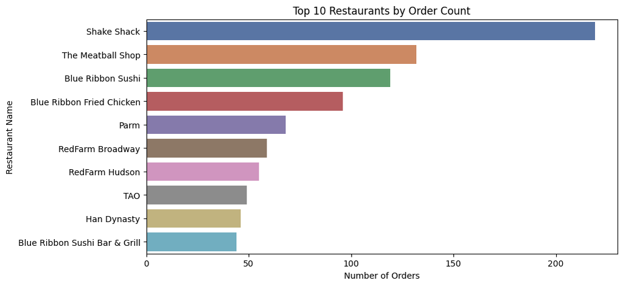

```python
graphTopRestaurants(10)
```

```python
# Get the value counts for the 'restaurant_name' column and take the top 5
top_5_restaurants = df['restaurant_name'].value_counts().head(5)

print("Top 5 restaurants (by # of orders received)")
print(top_5_restaurants)
```

```
Top 5 restaurants (by # of orders received)
restaurant_name
Shake Shack                  219
The Meatball Shop            132
Blue Ribbon Sushi            119
Blue Ribbon Fried Chicken     96
Parm                          68
Name: count, dtype: int64
```

#### Observations:

```
Top 5 restaurants (by # of orders received)
restaurant_name
Shake Shack                  219
The Meatball Shop            132
Blue Ribbon Sushi            119
Blue Ribbon Fried Chicken     96
Parm                          68
```

### **Question 8**: Which is the most popular cuisine on weekends? [1 mark]

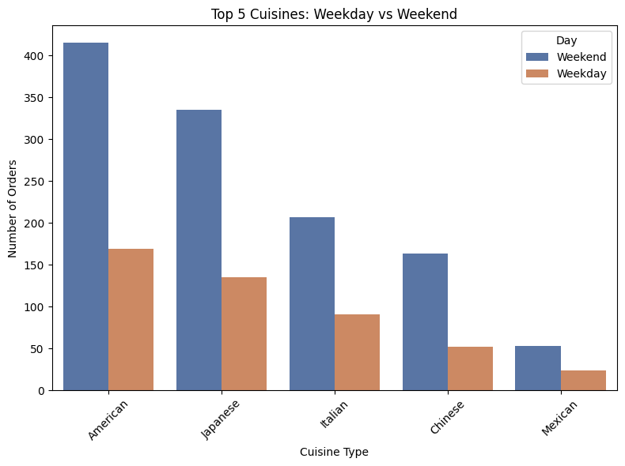

```python
top_n = 5
top_cuisines = df['cuisine_type'].value_counts().nlargest(top_n).index

plt.figure(figsize=(8, 6))
sns.countplot(
    data=df,
    x='cuisine_type',
    hue='day_of_the_week',
    order=top_cuisines,
    palette='deep'
)
plt.title(f"Top {top_n} Cuisines: Weekday vs Weekend")
plt.xlabel("Cuisine Type")
plt.ylabel("Number of Orders")
plt.legend(title="Day")
plt.xticks(rotation=45)
plt.tight_layout()
plt.show()
```

```python
# What is the most popular cuisine on the weekend
weekend_cuisines = df[df['day_of_the_week'] == 'Weekend']['cuisine_type'].value_counts()
most_popular_weekend_cuisine_order_count = weekend_cuisines.max()
most_popular_weekend_cuisine = weekend_cuisines.idxmax()
print(f"The most popular cuisine on the weekend is: [{most_popular_weekend_cuisine}] with {most_popular_weekend_cuisine_order_count} orders")
```

```
The most popular cuisine on the weekend is: [American] with 415 orders
```

#### Observations:

```
The most popular cuisine on the weekend is: [American] with 415 orders
```

### **Question 9**: What percentage of the orders cost more than 20 dollars? [2 marks]

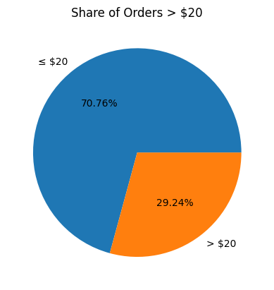

```python
per_over_20_mask = df['cost_of_the_order'] > 20
per_over_20_counts = per_over_20_mask.value_counts().sort_index()

plt.figure()
plt.pie(per_over_20_counts, labels=['≤ $20','> $20'], autopct='%.2f%%')
plt.title('Share of Orders > $20')
plt.show()
```

```python
percentage_over_20 = (per_over_20_mask).mean() * 100
print(f"Percentage of orders that cost more than 20 dollars: {percentage_over_20:.2f}%")
```

```
Percentage of orders that cost more than 20 dollars: 29.24%
```

#### Observations:

```
Percentage of orders that cost more than 20 dollars: 29.24%
```

### **Question 10**: What is the mean order delivery time? [1 mark]

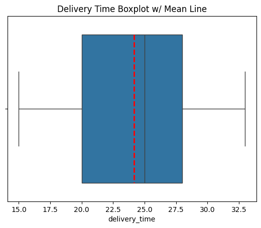

```python
sns.boxplot(
    x=df['delivery_time'],
    showmeans=True,
    meanline=True,
    meanprops={'linestyle':'--','linewidth':2,'color':'red'}
)
plt.title("Delivery Time Boxplot w/ Mean Line")
plt.show()
```

```python
mean_delivery_time = df['delivery_time'].mean()
print(f"Mean order delivery time: {mean_delivery_time:.2f} minutes")
```

```
Mean order delivery time: 24.16 minutes
```

#### Observations:

```
Mean order delivery time: 24.16 minutes
```

### **Question 11:** The company has decided to give 20% discount vouchers to the top 3 most frequent customers. Find the IDs of these customers and the number of orders they placed. [1 mark]

```python
df['customer_id'].value_counts().head(3)
```

| customer_id | count |
| --- | --- |
| 52832 | 13 |
| 47440 | 10 |
| 83287 | 9 |

**dtype:** int64

#### Observations:

```
customer_id	  count
52832	        13
47440	        10
83287	        9
```

### **Question 12**: Perform a multivariate analysis to explore relationships between the important variables in the dataset. (It is a good idea to explore relations between numerical variables as well as relations between numerical and categorical variables) [10 marks]

```python
numeric_cols = ['cost_of_the_order', 'food_preparation_time', 'delivery_time']
categorical_cols = ['cuisine_type', 'day_of_the_week', 'rating']

df['total_time'] = df['food_preparation_time'] + df['delivery_time']
df['rating_num'] = pd.to_numeric(df['rating'], errors='coerce')

numeric_cols = ['cost_of_the_order', 'food_preparation_time', 'delivery_time', 'total_time', 'rating_num']
```

```python
df.head()
```

|  | order_id | customer_id | restaurant_name | cuisine_type | cost_of_the_order | day_of_the_week | rating | food_preparation_time | delivery_time | total_time | rating_num |
| --- | --- | --- | --- | --- | --- | --- | --- | --- | --- | --- | --- |
| 0 | 1477147 | 337525 | Hangawi | Korean | 30.75 | Weekend | Not given | 25 | 20 | 45 | NaN |
| 1 | 1477685 | 358141 | Blue Ribbon Sushi Izakaya | Japanese | 12.08 | Weekend | Not given | 25 | 23 | 48 | NaN |
| 2 | 1477070 | 66393 | Cafe Habana | Mexican | 12.23 | Weekday | 5 | 23 | 28 | 51 | 5.0 |
| 3 | 1477334 | 106968 | Blue Ribbon Fried Chicken | American | 29.20 | Weekend | 3 | 25 | 15 | 40 | 3.0 |
| 4 | 1478249 | 76942 | Dirty Bird to Go | American | 11.59 | Weekday | 4 | 25 | 24 | 49 | 4.0 |

### Heatmap plot

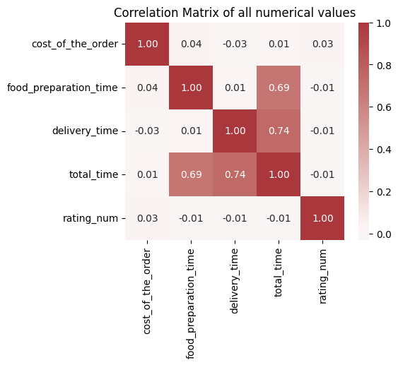

```python
corr = df[numeric_cols].corr()

plt.figure(figsize=(5,4))
sns.heatmap(corr, annot=True, fmt=".2f", cmap="vlag", center=0)
plt.title("Correlation Matrix of all numerical values")
plt.show()
```

No strong link between cost, total time, and rating...

might be worth looking elsewhere.

### Exploring multivariate plots on User Ratings

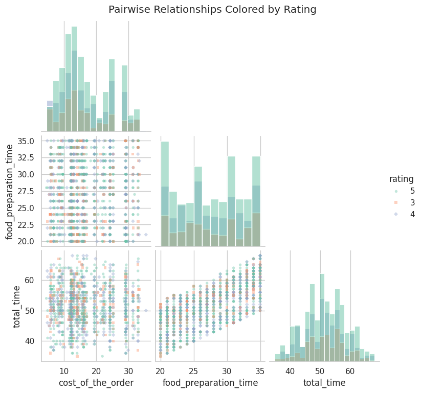

```python
# Clusters or shifts per rating: do 5-star orders tend to have faster delivery?
numeric_cols = ['cost_of_the_order', 'food_preparation_time', 'total_time']

sns.pairplot(
    df[df['rating'] != 'Not given'],
    vars=numeric_cols,
    hue='rating',
    palette='Set2',
    corner=True,
    diag_kind='hist',
    plot_kws={
        's': 15,
        'alpha': 0.4,
        'linewidth': 0,
    },
    markers=['o', 's', 'D']
)
plt.suptitle("Pairwise Relationships Colored by Rating", y=1.02)
plt.show()
```

No strong signals of order and delivery time linking to higher or lower ratings.

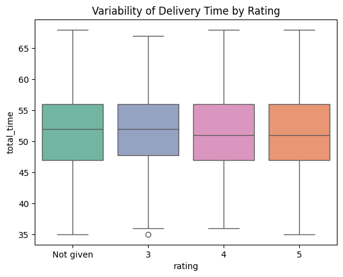

```python
sns.boxplot(
    data=df,
    x='rating',
    hue= 'rating',
    y='total_time',
    order=['Not given','3','4','5'],
    palette='Set2')
plt.title("Variability of Delivery Time by Rating")
plt.show()
```

This shows us that people are more focused on rating (assuming) the food quality than they are on rating the service of the delivery.

Probably worth finding out more of the 'Not given' rating.

There could be some patterns hidden behind it. like the food was so good or so bad that the customer decided not to give a rating.

### Exploring Relationships with Cuisine Types

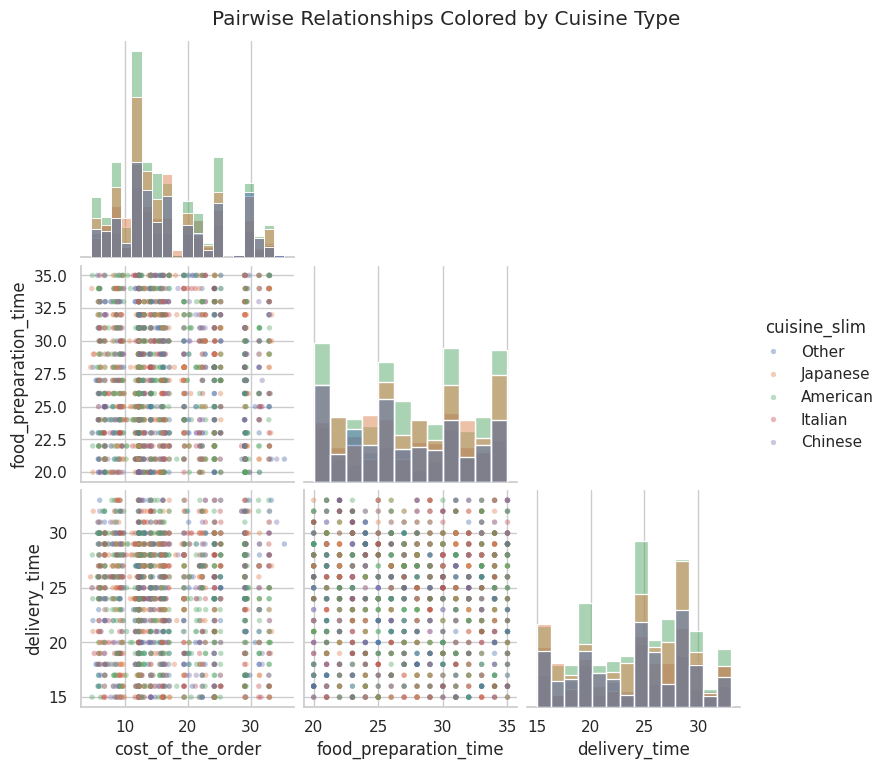

```python
vars_to_plot = ['cost_of_the_order','food_preparation_time', 'delivery_time']

top4 = df['cuisine_type'].value_counts().nlargest(4).index.tolist()
df['cuisine_slim'] = df['cuisine_type'].where(df['cuisine_type'].isin(top4), 'Other')

sns.pairplot(
    df,
    vars=vars_to_plot,
    hue='cuisine_slim',
    palette='deep',
    corner=True,
    diag_kind='hist',
    plot_kws={
        's': 15,
        'alpha': 0.4,
        'linewidth': 0,
    },
    height=2.5
)

plt.suptitle("Pairwise Relationships Colored by Cuisine Type", y=1.02)
plt.show()
```

It's hard to read association to Cuisines because of how many different types of cuisines there are.

Instead of pairplots I will try different plot types to read more into other cuisine type associations in the data.

### Better view of relationships between Cuisine Types and User Experience

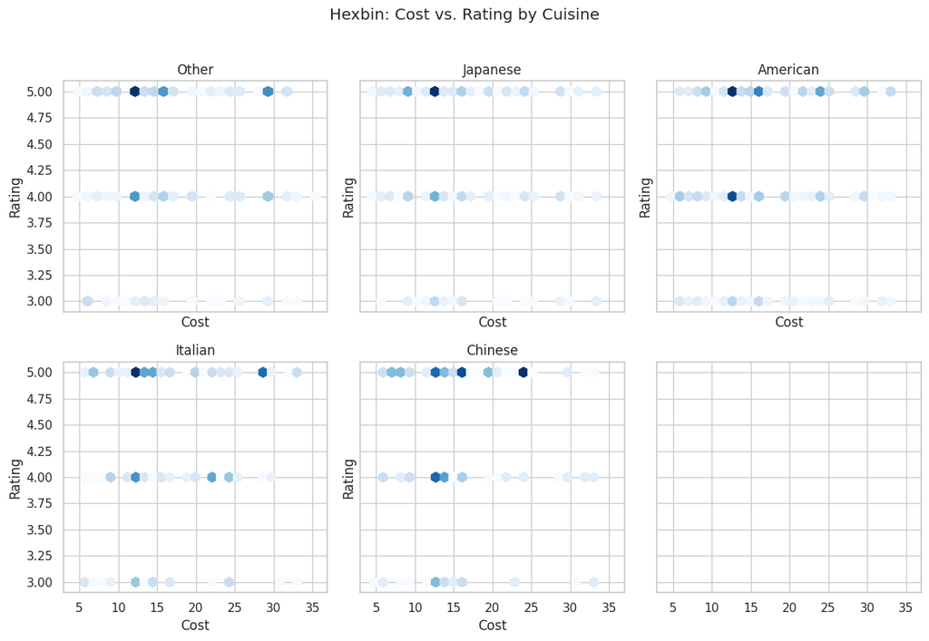

```python
fig, axes = plt.subplots(2, 3, figsize=(12, 8), sharex=True, sharey=True)
axes = axes.flatten()

for ax, cuisine in zip(axes, df['cuisine_slim'].unique()):
    subset = df[df['cuisine_slim'] == cuisine]
    hb = ax.hexbin(
        subset['cost_of_the_order'],
        subset['rating_num'],
        gridsize=25,
        cmap="Blues",
        mincnt=1
    )
    ax.set_title(cuisine)
    ax.set_xlabel("Cost")
    ax.set_ylabel("Rating")

plt.suptitle("Hexbin: Cost vs. Rating by Cuisine", y=1.02)
plt.tight_layout()
plt.show()
```

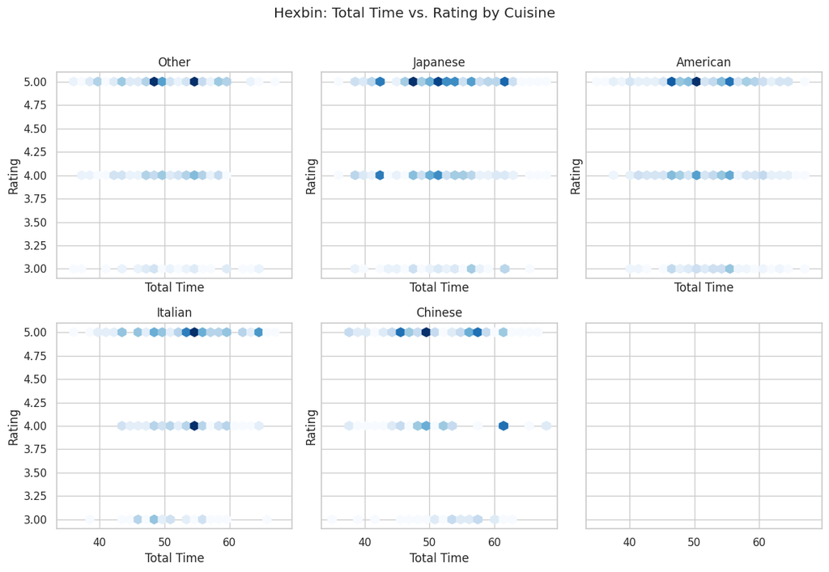

```python
fig, axes = plt.subplots(2, 3, figsize=(12, 8), sharex=True, sharey=True)
axes = axes.flatten()

for ax, cuisine in zip(axes, df['cuisine_slim'].unique()):
    subset = df[df['cuisine_slim'] == cuisine]
    hb = ax.hexbin(
        subset['total_time'],
        subset['rating_num'],
        gridsize=25,
        cmap="Blues",
        mincnt=1
    )
    ax.set_title(cuisine)
    ax.set_xlabel("Total Time")
    ax.set_ylabel("Rating")

plt.suptitle("Hexbin: Total Time vs. Rating by Cuisine", y=1.02)
plt.tight_layout()
plt.show()
```

The hexplot allows us to see associations of Rating, Total time and Cuisine type easily. But we can see that no definitive links between cuisine types and the two other columns are there for ratings.

This seems to mean that there's not much of an association between ratings and people experiences differentiated by the cuisine type.

It's a good sign that each cuisine type isn't causing a variation in customer experience.

### A deeper dive into User Experience and Ratings

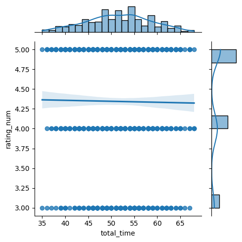

```python
sns.jointplot(
    data=df,
    x='total_time',
    y='rating_num',
    kind='reg',
    height=5
)
plt.tight_layout()
```

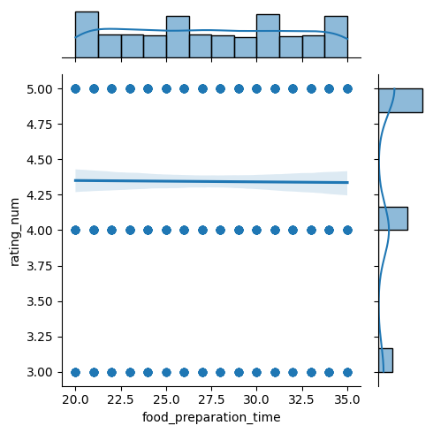

```python
sns.jointplot(
    data=df,
    x='food_preparation_time',
    y='rating_num',
    kind='reg',
    height=5
)
plt.tight_layout()
```

You can notice a little bit of rating decreasing as total time takes longer to be delivered.

It's not a huge dropoff in rating so there's nothing alarming to look at here.

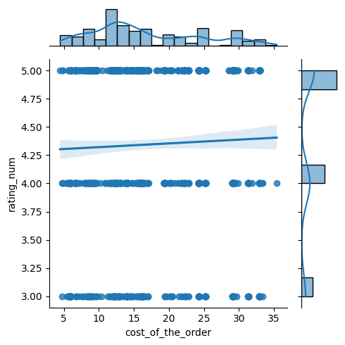

```python
sns.jointplot(
    data=df,
    x='cost_of_the_order',
    y='rating_num',
    kind='reg',
    height=5
)
plt.tight_layout()
```

Or people who tend to lean on the app to deliver higher cost food tend to have favorable opinion on their experiences.

### Exploring relationships in the data by Day of the Week

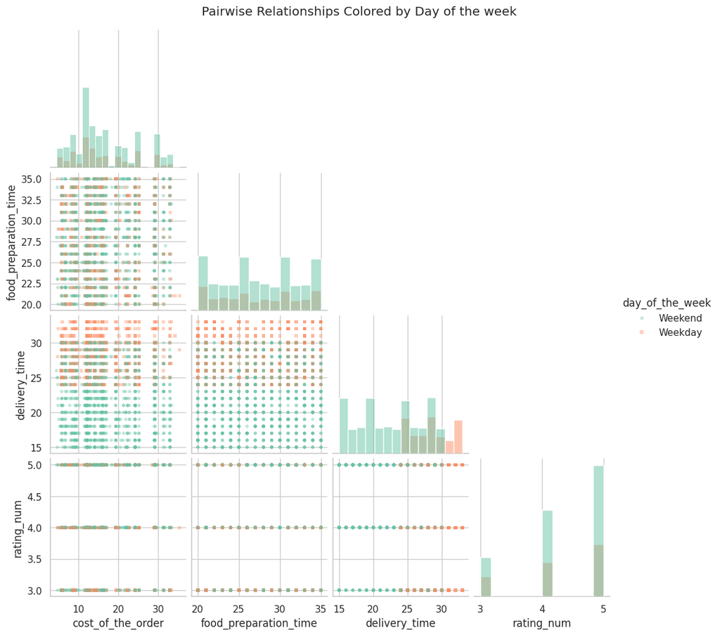

```python
numeric_cols = ['cost_of_the_order', 'food_preparation_time', 'delivery_time', 'rating_num']

sns.pairplot(
    df,
    vars=numeric_cols,
    hue='day_of_the_week',
    palette='Set2',
    corner=True,
    diag_kind='hist',
    plot_kws={
        's': 15,
        'alpha': 0.4,
        'linewidth': 0,
    },
    markers=['o', 's']
)
plt.suptitle("Pairwise Relationships Colored by Day of the week", y=1.02)
plt.show()
```

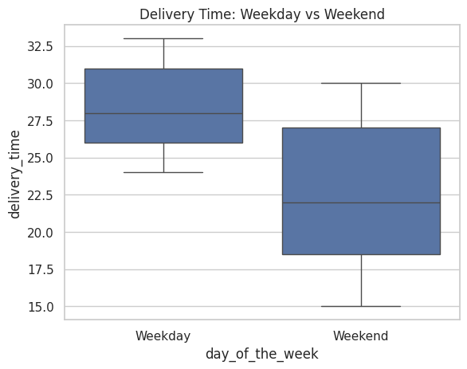

```python
# Whether weekends see longer tails in delivery times
sns.boxplot(
    data=df, x='day_of_the_week', y='delivery_time',
    order=['Weekday','Weekend']
)
plt.title("Delivery Time: Weekday vs Weekend")
plt.show()
```

This is important information that can be an enabler for growth the service to lean into. More advertising on the weekends can leverage user behavior towards supporting the service growth.

### Deeper dive into the data's variations by Cuisine Types

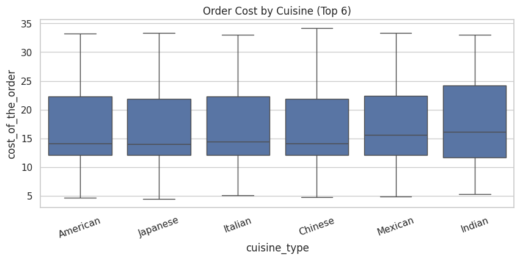

```python
# Which cuisine has the highest median cost or the biggest spread

plt.figure(figsize=(10,4))
sns.boxplot(
    data=df,
    x='cuisine_type',
    y='cost_of_the_order',
    order=df['cuisine_type'].value_counts().index[:6]
)
plt.xticks(rotation=20)
plt.title("Order Cost by Cuisine (Top 6)")
plt.show()
```

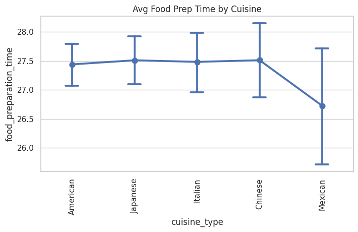

```python
# order by the cusines that take fastest to longest on average to prep
# top five cuisine
top_5_cuisine = df['cuisine_type'].value_counts().nlargest(5).index

plt.figure(figsize=(8,4))
sns.pointplot(x='cuisine_type', y='food_preparation_time', data=df, order=top_5_cuisine, capsize=.2)
plt.title("Avg Food Prep Time by Cuisine")
plt.xticks(rotation=90)
plt.show()
```

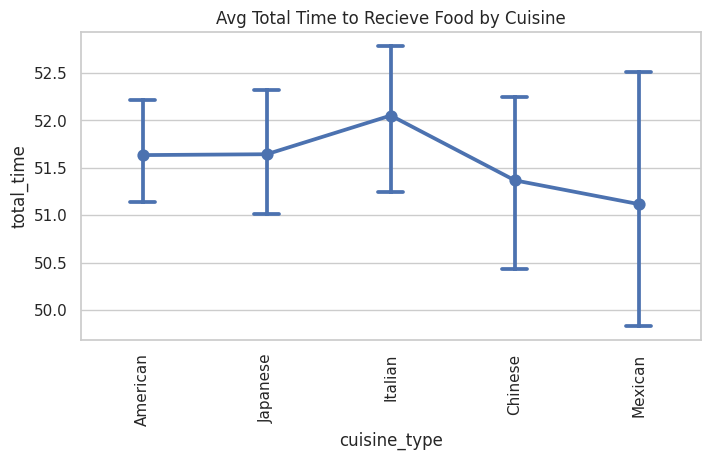

```python
plt.figure(figsize=(8,4))
sns.pointplot(x='cuisine_type', y='total_time', data=df, order=top_5_cuisine, capsize=.2)
plt.title("Avg Total Time to Recieve Food by Cuisine")
plt.xticks(rotation=90)
plt.show()
```

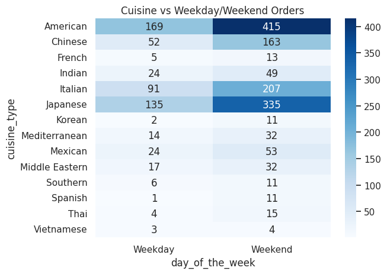

```python
ct = pd.crosstab(df.cuisine_type, df.day_of_the_week)
sns.heatmap(ct, annot=True, fmt='d', cmap='Blues')
plt.title("Cuisine vs Weekday/Weekend Orders")
plt.show()
```

I was exploring other relationships with Cuisine types to see if there are stand out observations.

### Deeper dive into the data by Day of the Week

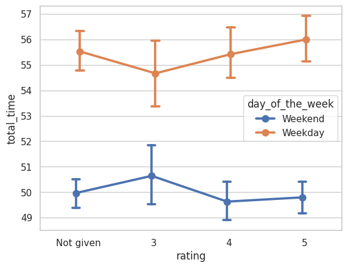

```python
sns.pointplot(
  data=df,
  x='rating',
  y='total_time',
  hue='day_of_the_week',
  order=['Not given','3','4','5'],
  dodge=True,
  capsize=0.1
)
plt.show()
```

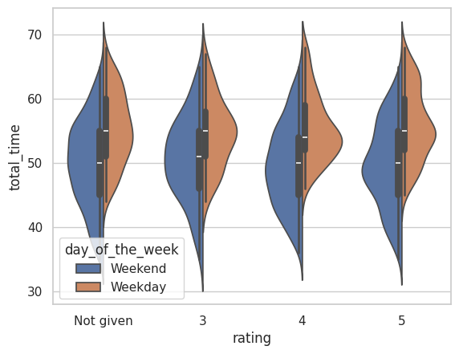

```python
sns.violinplot(x='rating',
               y='total_time',
               hue='day_of_the_week',
               split=True,
               data=df,
               order=['Not given','3','4','5'])
plt.show()
```

While most of the data shows more weekday and weekend efficiency difference, another interesting thing we can notice with the ratings data is that, slower time on weekday seems higher rating while faster time on weekend sees higher rating.

This seems to capture some difference in expectations from customers. Those expecting better quality food and those expecting faster service. The ratings alone might not be able to capture the different needs entirely.

Possible story behind the data can be that on weekdays users are expecting quality meal and not necessarily care about the time. While on weekends users tend to expect both quality and speed.

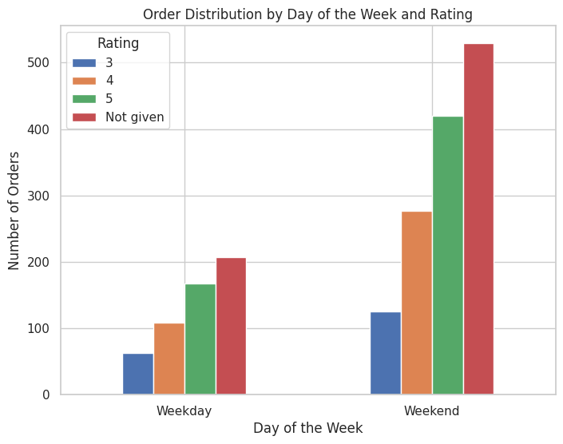

```python
# prompt: Show ratings to order distribution on the day_of_the_week using a visual graph

import matplotlib.pyplot as plt
# Group data by day of the week and rating, then count occurrences
rating_day = df.groupby(['day_of_the_week', 'rating']).size().unstack(fill_value=0)

# Create a bar plot
rating_day.plot(kind='bar', stacked=False, figsize=(8, 6))
plt.title('Order Distribution by Day of the Week and Rating')
plt.xlabel('Day of the Week')
plt.ylabel('Number of Orders')
plt.xticks(rotation=0)
plt.legend(title='Rating')
plt.show()
```

You see much higher engagement on orders and ratings on weekends.

Definitely leaning into the weekend for engagement will see higher response.

But we can't ignore the low engagement on the weekday. It will also be beneficial to explore how to capture demographics that seek the service on the weedays and study their behaviors as well.

```
Percent difference in order count between weekends and weekdays: 146.98%

Rating distribution on Weekends:
rating
Not given    39.156181
5            31.088083
4            20.503331
3             9.252406
Name: proportion, dtype: float64

Rating distribution on Weekdays:
rating
Not given    37.842779
5            30.712980
4            19.926874
3            11.517367
Name: proportion, dtype: float64
```

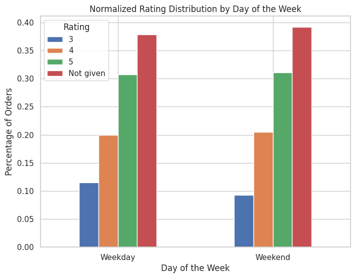

```python
# prompt: Show the percent difference between the ratings on weekends and weekdays based on order count

import matplotlib.pyplot as plt
# Separate orders into weekend and weekday
weekend_orders = df[df['day_of_the_week'] == 'Weekend']
weekday_orders = df[df['day_of_the_week'] == 'Weekday']

# Get the total order count for each
total_weekend_orders = weekend_orders.shape[0]
total_weekday_orders = weekday_orders.shape[0]

# Calculate the percent difference
# Using the weekday count as the baseline for the percentage calculation
# Formula: ((Value on Weekend - Value on Weekday) / Value on Weekday) * 100
if total_weekday_orders > 0:
  percent_difference = ((total_weekend_orders - total_weekday_orders) / total_weekday_orders) * 100
  print(f"Percent difference in order count between weekends and weekdays: {percent_difference:.2f}%")
else:
  print("Cannot calculate percent difference as there are no weekday orders.")

# To also show the distribution of ratings within weekends and weekdays
print("\nRating distribution on Weekends:")
print(weekend_orders['rating'].value_counts(normalize=True) * 100)

print("\nRating distribution on Weekdays:")
print(weekday_orders['rating'].value_counts(normalize=True) * 100)

# Let's also visualize the rating distribution on weekends vs weekdays
rating_distribution = df.groupby('day_of_the_week')['rating'].value_counts(normalize=True).unstack()

rating_distribution.plot(kind='bar', stacked=False, figsize=(8, 6))
plt.title('Normalized Rating Distribution by Day of the Week')
plt.xlabel('Day of the Week')
plt.ylabel('Percentage of Orders')
plt.xticks(rotation=0)
plt.legend(title='Rating')
plt.show()
```

Exploring to see if Weekday and Weekends sees different user engagement.

They seem to be just about the same. when the data is normalized